# What’s the Next Word

## Text Prediction Model

- A model to express yourself faster
- Our model predicts the next word for your text input
- Model has been trained based on the blogs, news and twitter text data provided for this app development project by JHU and Swiftkey
- Here we have created mainly bi-gram, tri-gram and quad-gram corpora for our model prediction algorithm
- For reducing the computational load only 0.1 fraction of the whole availabe data has been utilized

## Sample n-gram

A sorted Quadgram

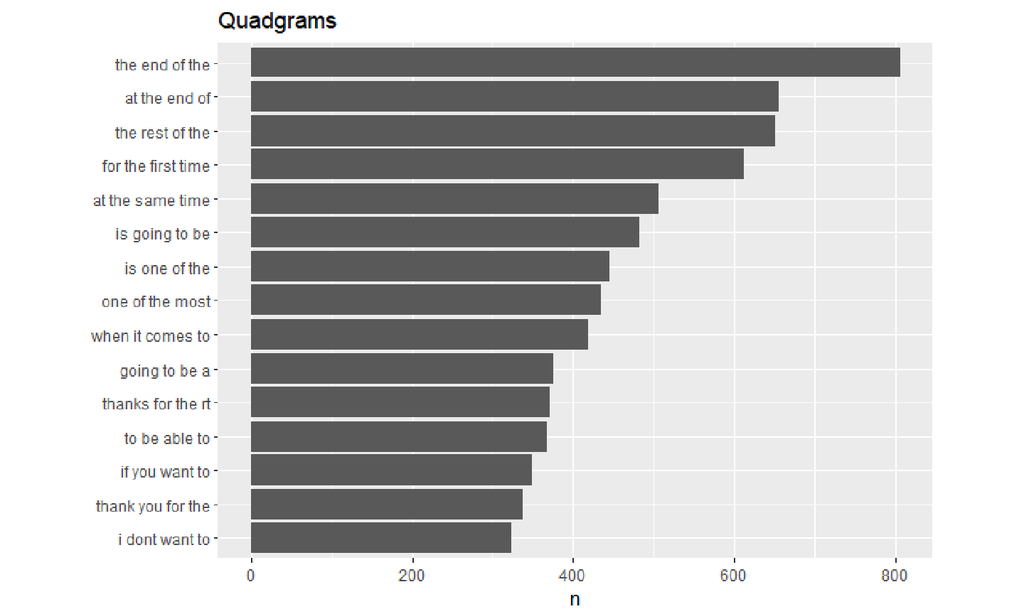

## Prediction Model

**Find word count, separate words, lower case**  
input_count <- str_count(input, boundary(“word”))  
input_words <- unlist(str_split(input, boundary(“word”)))  
input_words <- tolower(input_words)

**Look for the matching functions**  
out <- ifelse(input_count == 0, “Please input a phrase”,  
ifelse(input_count == 3, quadgram(input_words),  
ifelse(input_count == 2, trigram(input_words), bigram(input_words))))

## Prediction Model (Cntd.)

**Function Example**

*(Using the Quadgram based function)*

num <- length(input_words)  
filter(quad_words,  
word1==input_words[num-2],  
word2==input_words[num-1], word3==input_words[num]) %>%  
top_n(1, n) %>%  
filter(row_number() == 1L) %>%  
select(num_range(“word”, 4)) %>%  
as.character() -> out

Similarly, other two functions (trigram and bigram) are written Based on the input word count particular function is used for prediction

## My Prediction App

[figure not shown]

[Click here for My Shiny App page](https://ssoumyas.shinyapps.io/predictNext/?_ga=2.35568033.1810603107.1598296878-17581542.1597859271)